# Process the first five plates of birds typed at 192 SNPs (on two plates of Fluidigm assays)

# Check on the extent of missing data, and drop high-missing loci

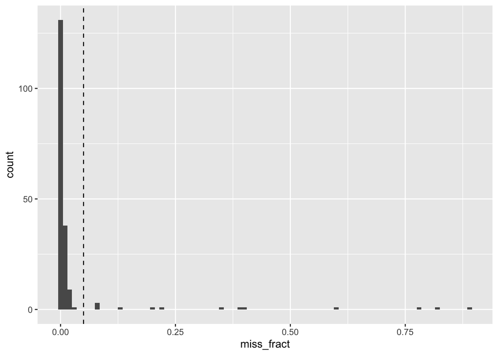

```r
miss_rates <- fluidigm_breeders_long %>%
  group_by(CHROMPOS) %>%
  summarise(miss_fract = mean(is.na(allele_ACGT)))

ggplot(miss_rates, aes(x = miss_fract)) +
  geom_histogram(binwidth = 0.01) +
  geom_vline(xintercept = 0.05, linetype = "dashed")
```

The dashed line there shows a 5% cutoff, which is what we applied to toss out other loci.

Here are the loci that we toss:

```r
toss_em <- miss_rates %>%
  filter(miss_fract > 0.05) %>%
  arrange(desc(miss_fract))

# have a look at all of them
left_join(
  miss_rates %>% arrange(desc(miss_fract)),
  assay_meta,
  by = c("CHROMPOS" = "CHROM")
)
```

| CHROMPOS | miss_fract | SNP_Name | REF | ALT |
| --- | --- | --- | --- | --- |
| scaffold135\|size1941959--1193205 | 0.890585242 | ada_Kern_1 | A | G |
| scaffold223\|size1722714--512747 | 0.819338422 | brew_ext_5 | C | T |
| scaffold22\|size5013007--1228893 | 0.776081425 | WM_Kern_3 | C | T |
| scaffold147\|size910788--866449 | 0.597964377 | climate_08 | A | G |
| scaffold343\|size799674--413363 | 0.399491094 | Kern_SD_7 | G | A |
| scaffold444\|size1099390--639627 | 0.389312977 | Ada_NS_7 | T | A |
| scaffold247\|size2371522--283574 | 0.351145038 | climate_15 | T | C |
| scaffold72\|size2462915--1777315 | 0.221374046 | ada_brew_4 | C | T |
| scaffold1236\|size281543--153250 | 0.201017812 | brew_ext_9 | C | T |
| scaffold27\|size3997909--2313808 | 0.127226463 | ext_pure_SD_1 | C | T |

[output cut: 182 more lines]

Remove those to make our final data set of Fluidigm-typed breeders and write it out.

```r
final_fluidigm_breeders_179_loci_393_birds_long <- fluidigm_breeders_long %>%
  anti_join(toss_em, by = "CHROMPOS")
write_rds(
  final_fluidigm_breeders_179_loci_393_birds_long,
  file = "outputs/003/final_fluidigm_breeders_179_loci_393_birds_long.rds",
  compress = "xz"
)
```

# Running Time

Running the code and rendering this notebook required approximately this much time on a Mac laptop of middling speed, listed in `HH:MM:SS`.

```r
td <- Sys.time() - start_time
tdf <- hms::as_hms(ceiling(hms::as_hms(td)))
dir.create("stored_run_times", showWarnings = FALSE, recursive = TRUE)
write_rds(tdf, "stored_run_times/003.rds")
tdf
```

```
## 00:00:16
```

Literature Cited